# 도로교통공단 맞춤형 통계분석 1일차

Sanghoo Yoon

# 데이터 탐색(dplyr)

**tidyverse**가 직관적인 코드로 구성되어 원래의 R 문법을 대체하고 있습니다.

가장 대표적인 표현은 `%>%`로 파이프라고 합니다.

`magrittr` 패키지의 **%>%** 연산자는 **Ctrl + Shift + M**으로 쉽게 입력하실 수 있습니다.

이 파이프를 잘 연결하면 코딩을 흘러가는데로 쉽게 작성할 수 있습니다.

```r
library(magrittr)
library(dplyr)
ex <- read.csv("F:/work/2022/1. 발표/교통안전공단/day1/diet.csv")
ex %>% head
```

```
##   Person gender Age Height pre.weight Diet weight6weeks
## 1     25     NA  41    171         60    2         60.0
## 2     26     NA  32    174        103    2        103.0
## 3      1      0  22    159         58    1         54.2
## 4      2      0  46    192         60    1         54.0
## 5      3      0  55    170         64    1         63.3
## 6      4      0  33    171         64    1         61.1
```

```r
ex %>% head(10)
```

```
##    Person gender Age Height pre.weight Diet weight6weeks
## 1      25     NA  41    171         60    2         60.0
## 2      26     NA  32    174        103    2        103.0
## 3       1      0  22    159         58    1         54.2
## 4       2      0  46    192         60    1         54.0
## 5       3      0  55    170         64    1         63.3
## 6       4      0  33    171         64    1         61.1
## 7       5      0  50    170         65    1         62.2
## 8       6      0  50    201         66    1         64.0
## 9       7      0  37    174         67    1         65.0
## 10      8      0  28    176         69    1         60.5
```

```r
ex %>% subset(gender==0) %>% head
```

```
##   Person gender Age Height pre.weight Diet weight6weeks
## 3      1      0  22    159         58    1         54.2
## 4      2      0  46    192         60    1         54.0
## 5      3      0  55    170         64    1         63.3
## 6      4      0  33    171         64    1         61.1
## 7      5      0  50    170         65    1         62.2
## 8      6      0  50    201         66    1         64.0
```

파이프는 여러 함수가 동시에 사용될때 가독성이 뛰어나며 `dplyr` 패키지의 함수와 사용시 활용가치가 높음을 알 수 있습니다.

`dplyr` 패키지는 데이터를 효과정으로 다룰 수 있는 함수를 제공합니다.

이중 group_by와 summarize는 집단별 통계량을 쉽게 구할 수 함수입니다.

## filter : 원하는 행만

filter는 엑셀의 필터와 같은 기능입니다. 데이터 중 내가 원하는 조건만 선택하고자 할때 이용됩니다.

예를 들어 키가 *170이상인 남자*만 선택한다고 하면

```r
library(dplyr)
ex %>% filter(gender==0 & Height>=170)
```

```
##    Person gender Age Height pre.weight Diet weight6weeks
## 1       2      0  46    192         60    1         54.0
## 2       3      0  55    170         64    1         63.3
## 3       4      0  33    171         64    1         61.1
## 4       5      0  50    170         65    1         62.2
## 5       6      0  50    201         66    1         64.0
## 6       7      0  37    174         67    1         65.0
## 7       8      0  28    176         69    1         60.5
## 8      11      0  60    173         72    1         70.5
## 9      27      0  44    174         58    2         60.1
## 10     28      0  37    172         58    2         56.0
## 11     30      0  43    171         61    2         56.7
## 12     32      0  51    174         63    2         62.4
## 13     34      0  54    173         63    2         59.4
## 14     61      0  37    170         70    3         62.7
## 15     62      0  31    170         72    3         71.1
## 16     63      0  35    171         72    3         64.4
## 17     64      0  56    171         73    3         68.9
```

연속형변수의 특정 범위는 between을 사용하여 쉽게 선택할 수 있다.

```r
ex %>% filter(between(Height,170,180)) %>% head
```

```
##   Person gender Age Height pre.weight Diet weight6weeks
## 1     25     NA  41    171         60    2         60.0
## 2     26     NA  32    174        103    2        103.0
## 3      3      0  55    170         64    1         63.3
## 4      4      0  33    171         64    1         61.1
## 5      5      0  50    170         65    1         62.2
## 6      7      0  37    174         67    1         65.0
```

`|`는 또는 (or)에 사용되는 연산자입니다.

%in% 연산자를 이용하면 여러개를 동시에 선택할 수 있습니다.

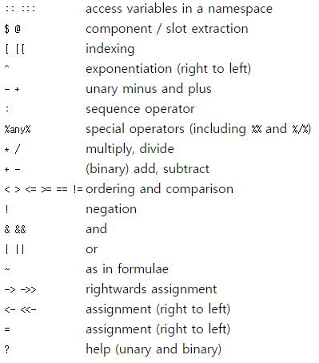

## arrange : 순서대로

arrange는 엑셀에서 정렬하기와 같은 기능입니다. 여러 변수를 오름차순, 내림차순으로 정렬할 수 있습니다. 기본적으로는 오름차순으로 정렬되며 내림차순을 사용할시 `desc`함수를 이용하면 됩니다. 정렬을 하고자 하는 변수를 입력하고 여러 변수가 있을 시 `,`를 사용하면 됩니다.

```r
ex %>% arrange(Age) %>% head(10)
```

```
##    Person gender Age Height pre.weight Diet weight6weeks
## 1      37      0  16    165         68    2         63.8
## 2      31      0  20    169         62    2         55.0
## 3      57      0  20    169         67    3         61.6
## 4      54      0  21    159         64    3         60.6
## 5       1      0  22    159         58    1         54.2
## 6      55      0  22    169         65    3         58.2
## 7      20      1  25    165         80    1         77.6
## 8      72      1  26    179         78    3         69.4
## 9       8      0  28    176         69    1         60.5
## 10      9      0  28    165         70    1         68.1
```

```r
ex %>% arrange(Diet, desc(pre.weight))
```

```
##    Person gender Age Height pre.weight Diet weight6weeks
## 1      24      1  40    190         88    1         84.5
## 2      23      1  39    166         87    1         81.9
## 3      22      1  42    166         85    1         81.5
## 4      21      1  52    177         83    1         79.1
## 5      14      0  37    167         82    1         81.1
## 6      19      1  43    162         80    1         71.0
## 7      20      1  25    165         80    1         77.6
## 8      18      1  50    160         78    1         73.9
## 9      17      1  40    173         74    1         69.5
## 10     11      0  60    173         72    1         70.5
## 11     12      0  48    156         72    1         69.0
## 12     13      0  41    163         72    1         68.4
## 13     16      1  31    158         72    1         70.9
## 14     15      1  39    168         71    1         71.6
```

[output cut: 64 more lines]

```r
ex %>% filter(!is.na(gender)) %>% arrange(Diet, desc(pre.weight))
```

```
##    Person gender Age Height pre.weight Diet weight6weeks
## 1      24      1  40    190         88    1         84.5
## 2      23      1  39    166         87    1         81.9
## 3      22      1  42    166         85    1         81.5
## 4      21      1  52    177         83    1         79.1
## 5      14      0  37    167         82    1         81.1
## 6      19      1  43    162         80    1         71.0
## 7      20      1  25    165         80    1         77.6
## 8      18      1  50    160         78    1         73.9
## 9      17      1  40    173         74    1         69.5
## 10     11      0  60    173         72    1         70.5
## 11     12      0  48    156         72    1         69.0
## 12     13      0  41    163         72    1         68.4
## 13     16      1  31    158         72    1         70.9
## 14     15      1  39    168         71    1         71.6
```

[output cut: 62 more lines]

## select : 변수선택

select는 엑셀에서 숨기기와 같이 관심이 있는 변수(열)만 선택하는 기능입니다.

많은 변수가 있는 빅데이터의 경우에는 너무 많은 변수가 있어 관심있는 변수 간 상관성을 파악하기 힘들 수 있으므로 중요 변수만 선택한 데이터만 생성하여 그 관계를 살펴볼 수 있습니다.

```r
ex %>% select(Height, pre.weight) %>% head
```

```
##   Height pre.weight
## 1    171         60
## 2    174        103
## 3    159         58
## 4    192         60
## 5    170         64
## 6    171         64
```

```r
head(ex[,c("Height", "pre.weight")])
```

```
##   Height pre.weight
## 1    171         60
## 2    174        103
## 3    159         58
## 4    192         60
## 5    170         64
## 6    171         64
```

**:**과 숫자를 사용해서 출력하는 것도 가능하다.

```r
ex %>% select(gender:Height) %>% head
```

```
##   gender Age Height
## 1     NA  41    171
## 2     NA  32    174
## 3      0  22    159
## 4      0  46    192
## 5      0  55    170
## 6      0  33    171
```

```r
ex %>% select("gender":"Height") %>% head
```

```
##   gender Age Height
## 1     NA  41    171
## 2     NA  32    174
## 3      0  22    159
## 4      0  46    192
## 5      0  55    170
## 6      0  33    171
```

```r
ex %>% select(2,3,4) %>% head
```

```
##   gender Age Height
## 1     NA  41    171
## 2     NA  32    174
## 3      0  22    159
## 4      0  46    192
## 5      0  55    170
## 6      0  33    171
```

```r
ex %>% select(c(2,3,4)) %>% head
```

```
##   gender Age Height
## 1     NA  41    171
## 2     NA  32    174
## 3      0  22    159
## 4      0  46    192
## 5      0  55    170
## 6      0  33    171
```

특정 변수는 `-`를 넣으면 된다.

```r
ex %>% select(-2,-3,-4) %>% head
```

```
##   Person pre.weight Diet weight6weeks
## 1     25         60    2         60.0
## 2     26        103    2        103.0
## 3      1         58    1         54.2
## 4      2         60    1         54.0
## 5      3         64    1         63.3
## 6      4         64    1         61.1
```

```r
ex %>% select(-gender,-Age,-Height) %>% head
```

```
##   Person pre.weight Diet weight6weeks
## 1     25         60    2         60.0
## 2     26        103    2        103.0
## 3      1         58    1         54.2
## 4      2         60    1         54.0
## 5      3         64    1         63.3
## 6      4         64    1         61.1
```

이 외에 select와 함께 유용하게 사용할 수 있는 함수는

- start_with(“abc”): ’abc’로 시작하는 이름
- end_with(“xyz”): ’xyz’로 끝나는 이름
- contains(“ijk”): ’ijk’를 포함하는 이름
- one_of(c(“a”, “b”, “c”)): 변수명이 a, b, c 중 하나
- matches(“(.)\1”): 정규표현식 조건
- num_range(“x”, 1:3): x1, x2, x3

## mutate : 새로운 변수 정의

mutate는 기존에 있는 변수 외에 새로운 변수를 만들 때 사용하는 함수이다.

BMI와 같이 키와 몸무게가 있는 경우 식을 통해 새로운 변수를 만들 수 있다.

또는 연속형 자료로된 나이를 20대, 30대, 40대와 같은 연령대인 범주형자료로 바꿀 수 있다.

$$BMI = {{Weight} \over {Height^2}}$$

BMI가 18.5 이하 : “저체중”, 18.5~23 : “정상”, 23~25 : “과체중”, 25~ : “비만” 이다.

mutate함수와 pre.weight를 이용하여 계산하자.

> 기존 자료에 %>% 만 연결하면 수정된 자료가 만들어 지지 않는다.

> 새로 생성된 변수가 반영된 데이터를 사용하기 위해선 `<-`를 이용해 새로운 이름으로 데이터를 명명하자.

```r
ex1 <- ex %>% mutate(BMI.pre = pre.weight/(Height^2)*10000) # 키의 단위는 m이므로 곱하기 10000
ex1 %>% mutate(BMI.c = ifelse(BMI.pre<=18.5,"저체중",
                              ifelse(BMI.pre<=23,"정상",
                                     ifelse(BMI.pre<=25,"과제중","비만"))))
```

```
##    Person gender Age Height pre.weight Diet weight6weeks  BMI.pre  BMI.c
## 1      25     NA  41    171         60    2         60.0 20.51913   정상
## 2      26     NA  32    174        103    2        103.0 34.02035   비만
## 3       1      0  22    159         58    1         54.2 22.94213   정상
## 4       2      0  46    192         60    1         54.0 16.27604 저체중
## 5       3      0  55    170         64    1         63.3 22.14533   정상
## 6       4      0  33    171         64    1         61.1 21.88708   정상
## 7       5      0  50    170         65    1         62.2 22.49135   정상
## 8       6      0  50    201         66    1         64.0 16.33623 저체중
## 9       7      0  37    174         67    1         65.0 22.12974   정상
## 10      8      0  28    176         69    1         60.5 22.27531   정상
## 11      9      0  28    165         70    1         68.1 25.71166   비만
## 12     10      0  45    165         70    1         66.9 25.71166   비만
## 13     11      0  60    173         72    1         70.5 24.05693 과제중
## 14     12      0  48    156         72    1         69.0 29.58580   비만
```

[output cut: 64 more lines]

### Question

1. 다이어트 후의 BMI를 BMI.after로 만드세요.
2. 다이어트 전과 후의 BMI 차이를 계산해보세요.

transmute함수를 이용하면 새로운 변수값만 볼 수 있다.

```r
ex1 %>% transmute(OverWeight = as.integer(BMI.pre>27))
```

```
##    OverWeight
## 1           0
## 2           1
## 3           0
## 4           0
## 5           0
## 6           0
## 7           0
## 8           0
## 9           0
## 10          0
## 11          0
## 12          0
## 13          0
## 14          1
```

[output cut: 64 more lines]

## group_by : 집단별로

group_by를 사용하면 집단 별 결과를 알 수 있다.

이를 사용하면 집단별로 상위 또는 사위 3개도 쉽게 구할 수 있다.

```r
ex %>% select(Diet) %>% table
```

```
## .
##  1  2  3
## 24 27 27
```

```r
ex %>% select(Diet, gender) %>% group_by(gender) %>% table
```

```
##     gender
## Diet  0  1
##    1 14 10
##    2 14 11
##    3 15 12
```

```r
ex %>% filter(!is.na(gender)) %>% group_by(gender) %>% arrange(desc(Age)) %>% do(head(., n=3))
```

```
## # A tibble: 6 x 7
## # Groups:   gender [2]
##   Person gender   Age Height pre.weight  Diet weight6weeks
##    <int>  <int> <int>  <int>      <int> <int>        <dbl>
## 1     11      0    60    173         72     1         70.5
## 2     60      0    58    141         70     3         63
## 3     64      0    56    171         73     3         68.9
## 4     43      1    54    196         75     2         69.2
## 5     21      1    52    177         83     1         79.1
## 6     41      1    51    191         71     2         66.8
```

## summarize : 집단요약

많은 수의 집단을 요약할 때 사용하는 함수로 대푯값, 산포도, 빈도가 주로 사용된다.

대푯값 : 평균, 중위수, 최빈값 산포도 : 분산, 표준편차, 범위, 등

summarize함수는 group_by와 함께 사용할때 이용가치가 높으며 기본 R에서는 aggregate 함수가 사용된다.

T검정, 분산분석과 함께 사용하면 좋다.

```r
ex1 %>% filter(!is.na(gender)) %>%
                 group_by(gender) %>%
                 summarize(count=n(), meanBMI=mean(BMI.pre), sdBMI=sd(BMI.pre))
```

```
## # A tibble: 2 x 4
##   gender count meanBMI sdBMI
##    <int> <int>   <dbl> <dbl>
## 1      0    43    24.2  3.81
## 2      1    33    26.1  3.87
```

만약 summarize_all을 사용하면 모든 변수에 적용된다.

```r
ex %>% summarize_all(mean)
```

```
##   Person gender      Age   Height pre.weight     Diet weight6weeks
## 1   39.5     NA 39.15385 170.8205   72.52564 2.038462     68.68077
```

filter와 group_by를 사용하여 40세 이상, gender=0인 다이어트 전과 후의 몸무게를 살펴본다면…

```r
ex %>% filter(Age>=40 & gender==0 ) %>%
  group_by(Diet) %>%
  select(pre.weight, weight6weeks) %>%
  summarize_all(mean)
```

```
## # A tibble: 3 x 3
##    Diet pre.weight weight6weeks
##   <int>      <dbl>        <dbl>
## 1     1       67.6         64.8
## 2     2       62.1         60.3
## 3     3       70.5         64.4
```

# 데이터 정리해보기

## 연비자료 정리

[output not shown]

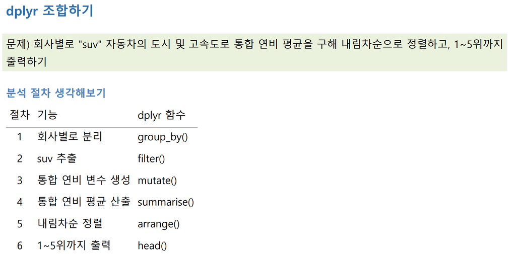

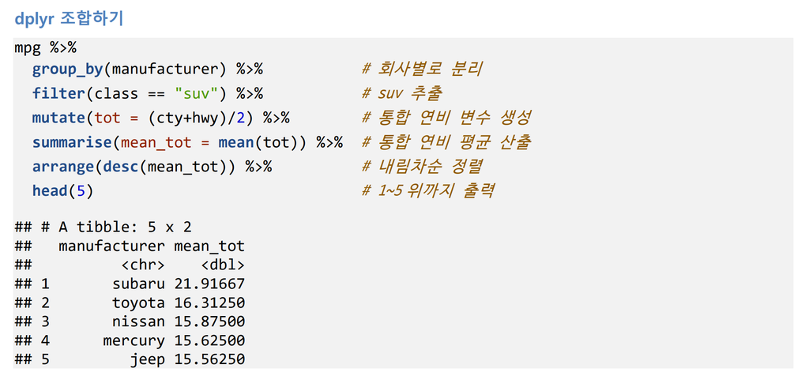

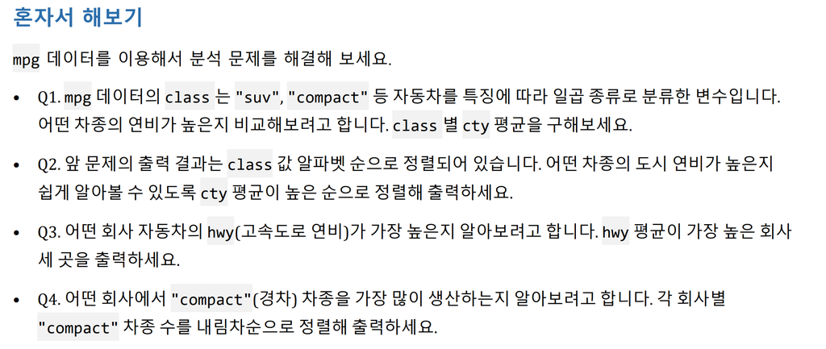

```r
library(ggplot2)
mpg <- as.data.frame(data(mpg))
head(mpg)
```

[output not shown]

## 이 외에 추가 공부

summarise_at 함수는 vars, funs를 이용하여 많은 변수의 요약값을 쉽게 생성할 수 있습니다.

### melt와 cast 함수를 이용한 데이터 재구조화

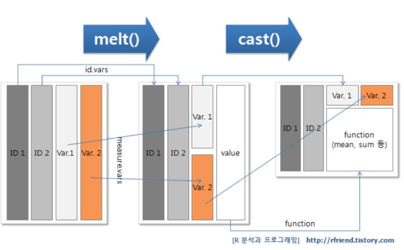

melt()와 cast() 함수는 자료를 녹여 다시 데이터프레임 형태로 만든 함수이다.

```r
df <- data.frame(고객id = c('a','a','a','b','c') ,
                 코너 = c('식료품', '식료품', '가전', '완구', '생활품'),
                 가격 = c(5000,7000,40000,98000,50000))
```

이렇게 생성된 함수를 고객별로 구매한 가격의 합 또는 갯수로 정리하고 싶다면?

```r
library(reshape)
df_1 <- cast(df, 고객id ~ 코너, sum)
df_1
```

```
##   고객id  가전 생활품 식료품  완구
## 1      a 40000      0  12000     0
## 2      b     0      0      0 98000
## 3      c     0  50000      0     0
```

```r
df_2 <- cast(df, 고객id ~ 코너, length)
df_2
```

```
##   고객id 가전 생활품 식료품 완구
## 1      a    1      0      2    0
## 2      b    0      0      0    1
## 3      c    0      1      0    0
```

만약 다시 원래의 자료형태로 변환하고자 한다면?

```r
df3 <- melt(df_1, id.vars = '고객id',measure.vars = c('가전','생활품','식료품','완구'))
df3
```

```
##          고객id value   코너
## 가전          a 40000   가전
## 가전.1        b     0   가전
## 가전.2        c     0   가전
## 생활품        a     0 생활품
## 생활품.1      b     0 생활품
## 생활품.2      c 50000 생활품
## 식료품        a 12000 식료품
## 식료품.1      b     0 식료품
## 식료품.2      c     0 식료품
## 완구          a     0   완구
## 완구.1        b 98000   완구
## 완구.2        c     0   완구
```

`melt`는 주로 데이터 시각화에 그리고 `cast`는 자료를 표로 정리할 때 많이 사용됩니다.